# Report Gruppe E

# Introduction and data

## Project Motivation

1999 wurde in der Forschung (Collins et al.) ermittelt, dass die ASA-Klassifizierung des körperlichen Zustands, das Alter, Bluttransfusionen während der Operation und die Dauer von Operationen einen Aufschluss darüber geben, ob der Krankenhausaufenthalt des Patienten länger als gewöhnlich ausfallen wird.

Des Weiteren gibt es zahlreiche Studien, bspw. die Forschung von Biber et al. (2012), Singler et al. (2013) oder Ogliari et al. (2022) die festgestellt haben, dass es eine Korrelation zwischen dem Alter von Patienten und der Verweildauer in Notaufnahmen gab.

Dieser Frage möchten wir gerne nachgehen und versuchen, die Aufenthaltsdauer vorherzusagen

## Data

Uns liegen Daten von nicht-kardiochirurgischen Patienten vor, welche sich von August 2016 bis Juni 2017 einer Routine- oder Notoperation am Seoul National University Hospital, Seoul, Korea, unterzogen. Von den 7.051 in Frage kommenden Fällen wurden Fälle mit lokaler Anästhesie (239), unvollständiger Aufzeichnung (279) und Verlust von wesentlichen Datenspuren (145) ausgeschlossen. Schließlich wurden 6.388 Fälle (91 %), die eine Allgemeinanästhesie, Spinalanästhesie und Sedierung/Analgesie erhielten, in den Datensatz aufgenommen. Der Datensatz besteht aus intraoperativen Vitaldaten und perioperativen klinischen Informationen von 6.388 Fällen.

Die Vitaldaten umfassen bis zu 12 Wellenform- und 184 numerische Datenspuren, die von mehreren Anästhesiegeräten erfasst wurden, die den Patienten während der Operation eingesetzt wurden.

Die Daten wurden nicht vorverarbeitet, da das reale Rauschen in den Vitaldaten für die Entwicklung praktischer Überwachungsalgorithmen sehr wichtig ist.

Insgesamt 74 perioperative klinische Informationsparameter und 34 Zeitreihen perioperativer Laborergebnisse werden zur Verfügung gestellt, um die Interpretation der Beziehung zu den intraoperativen Vitalzeichen zu erleichtern.

## Research Question

Wir stellen uns die Frage, welche dem Krankenhaus vorliegenden Daten die Aufenthaltsdauer von Patienten beeinflusst. Da der Datensatz des Seoul National University Hospital (Seoul, Korea) eine Vielzahl von möglichen Variablen enthält werden wir uns vorerst mit den Zusammenhang zwischen dem Alter der Patienten und der Behandlungsdauer beschäftigen.

```python
import pandas as pd
import altair as alt
import numpy as np
import joblib
import seaborn as sns
import matplotlib.pyplot as plt


from sklearn.feature_selection import SelectFromModel

from sklearn.model_selection import train_test_split
from sklearn.model_selection import cross_val_score
from sklearn.inspection import permutation_importance

from sklearn.linear_model import LinearRegression
from sklearn.metrics import r2_score
from sklearn.metrics import mean_squared_error
from sklearn.metrics import mean_absolute_error

from sklearn.preprocessing import StandardScaler
from sklearn.linear_model import LassoCV
from sklearn.linear_model import Lasso

from statsmodels.formula.api import ols

import warnings
warnings.simplefilter(action='ignore', category=FutureWarning)
alt.data_transformers.disable_max_rows()
```

```
DataTransformerRegistry.enable('default')
```

## Data preparation

Daten importieren

```python
df = pd.read_csv("https://raw.githubusercontent.com/Maarv99/Project-applied-statistics/main/data/raw/clinical_data.csv")
df_orig = df.copy()
```

Wir berechnen eine weitere Variable “op_duartion”. Sie zeigt die Dauer einer Operation an. Dafür subtrahieren wir von der Variablen “opend” die Variable “opstart”.

```python
df['op_duration']=df['opend']-df['opstart']
```

Wir benennen einige Variablen um:

- “caseend” bezeichnet das Ende eines Falls, vom Startpunkt 0, daher bennen wir diese Variable “record_duration”
- Die Variable “icu_days” bezeichnet die Aufenthaltsdauer im Krankenhaus (icu), daher bennen wir diese Variable “length_of_stay”
- Da wir uns unter der Variable “intraop_ebl” wenig vorstellen konnten, benennen wir diese in “estimated_blood_loss” um.

```python
df=df.rename(columns={'caseend':'recording_duration','icu_days':'length_of_stay','intraop_ebl':'estimated_blood_loss'})
```

Wir ändern nun den Datentyp der Variable “estimated_blood_loss”, sodass diese korrekt erkannt wird.

```python
df['estimated_blood_loss'] = df['estimated_blood_loss'].fillna(0).astype(int)
```

Die Spalte “age” enthält u.a. die Zeichen “>89” und “0.7”. Daher wird das Größer-als-Zeichen entfernt und die Werte gerundet, damit es zu int umwandelt werden kann.

```python
df['age'] = df['age'].str.replace('>89', '89').astype(float).round().astype(int)
```

Wir prüfen unsere Daten auf Zellen ohne Werte.

```python
print("Missing values in 'estimated_blood_loss':",df['estimated_blood_loss'].isnull().sum())
print("Missing values in 'op_duration':",df['op_duration'].isnull().sum())
print("Missing values in 'length_of_stay':",df['length_of_stay'].isnull().sum())
print("Missing values in 'bmi':",df['bmi'].isnull().sum())
print("Missing values in 'asa':",df['asa'].isnull().sum())
print("Missing values in 'age':",df['age'].isnull().sum())
print("Missing values in 'recording_duration':",df['recording_duration'].isnull().sum())
print("Missing values in 'sex':",df['sex'].isnull().sum())
```

```
Missing values in 'estimated_blood_loss': 0
Missing values in 'op_duration': 0
Missing values in 'length_of_stay': 0
Missing values in 'bmi': 0
Missing values in 'asa': 133
Missing values in 'age': 0
Missing values in 'recording_duration': 0
Missing values in 'sex': 0
```

Lediglich die Spalte ‘asa’ hat 133 NAs. Diese werden durch den Median der Spalte ersetzt.

Wir prüfen, ob der Vorgang korrekt durchgeführt wurde.

```python
df['asa'] = df['asa'].fillna(df['asa'].median())
print("Missing values in 'asa':",df['asa'].isnull().sum())
```

```
Missing values in 'asa': 0
```

Wir ändern Kategorische Werte in numerische und lassen uns die Daten einmal anzeigen:

```python
df = df[['estimated_blood_loss', 'op_duration', 'length_of_stay', 'bmi', 'asa', 'age', 'recording_duration', 'sex']]
```

```python
# Convert categorical into binary numeric format
df = pd.get_dummies(df)
df
```

|  | estimated_blood_loss | op_duration | length_of_stay | bmi | asa | age | recording_duration | sex_F | sex_M |
| --- | --- | --- | --- | --- | --- | --- | --- | --- | --- |
| 0 | 0 | 8700 | 0 | 26.3 | 2.0 | 77 | 11542 | 0 | 1 |
| 1 | 50 | 12900 | 0 | 19.6 | 2.0 | 54 | 15741 | 0 | 1 |
| 2 | 0 | 1920 | 0 | 24.4 | 1.0 | 62 | 4394 | 0 | 1 |
| 3 | 0 | 15300 | 1 | 20.5 | 2.0 | 74 | 20990 | 0 | 1 |
| 4 | 2600 | 17700 | 13 | 20.4 | 3.0 | 66 | 21531 | 0 | 1 |
| ... | ... | ... | ... | ... | ... | ... | ... | ... | ... |
| 6383 | 100 | 12000 | 0 | 24.2 | 1.0 | 64 | 15248 | 0 | 1 |
| 6384 | 100 | 17100 | 0 | 24.6 | 2.0 | 69 | 20643 | 0 | 1 |
| 6385 | 100 | 14700 | 0 | 18.8 | 1.0 | 61 | 19451 | 1 | 0 |
| 6386 | 0 | 9300 | 0 | 22.9 | 1.0 | 24 | 12025 | 1 | 0 |
| 6387 | 0 | 6900 | 0 | 22.9 | 2.0 | 47 | 10249 | 1 | 0 |

6388 rows × 9 columns

Wir schauen uns noch die Verteilung der Daten an:

```python
df=df[['recording_duration','age','asa','bmi','length_of_stay','op_duration','estimated_blood_loss','sex_F','sex_M']]


y_label = 'length_of_stay'

features = ['recording_duration',
            'age',
            'asa',
            'bmi',
            'op_duration',
            'estimated_blood_loss',
            'sex_F']

X = df[features]
y = df[y_label]
```

```python
alt.Chart(df).mark_circle().encode(
    alt.X(alt.repeat("column"), type='quantitative'),
    alt.Y(alt.repeat("row"), type='quantitative')
).properties(
    width=150,
    height=150
).repeat(
    row=['length_of_stay'],
    column=['age','asa','bmi','op_duration','estimated_blood_loss','sex_F','sex_M']
).interactive()
```

[interactive chart not shown]

Von den 6.388 Werten gibt es zwei Ausreißer. Wir betrachten uns daher “length_of_stay” bis zu 50 Tagen.

```python
df = df[df['length_of_stay']<50]
```

## Variablen

Aufgrund unserer Projektmotivation heraus nutzen wir die dort erwähnten Variablen. Zusätzlich nehmen wir noch die Variable “bmi” hinzu. Diese wird zwar nicht erwähnt, zeigt jedoch auf eine andere Art als die ASA-Klassifizierung (Variable “asa”) auch den Körperlichen Zustand eines Patienten. Aus der Projektmotivation ist auch zu entnehmen, dass wir die Krankenhausaufenhaltsdauer anhand dieser Prädiktoren bestimmen möchten.

```python
df=df[['recording_duration','age','asa','bmi','length_of_stay','op_duration','estimated_blood_loss','sex_F','sex_M']]


y_label = 'length_of_stay'

features = ['recording_duration',
            'age',
            'asa',
            'bmi',
            'op_duration',
            'estimated_blood_loss',
            'sex_F']

X = df[features]
y = df[y_label]
```

Wir möchten uns nun die Daten einmal einzeln anschauen:

```python
alt.Chart(df).mark_bar().encode(
    alt.X(alt.repeat("column"), type="quantitative", bin=True),
    y='count()',
).properties(
    width=150,
    height=150
).repeat(
    column=['length_of_stay','age','asa','bmi','op_duration','estimated_blood_loss','sex_F','sex_M']
)
```

[interactive chart not shown]

Nun Betrachten wir die Korrelation der Variablen:

```python
df[['length_of_stay','age','asa','bmi','op_duration','estimated_blood_loss','sex_F','sex_M']].corr()
corr = df.corr()
corr[y_label].sort_values(ascending=False)
corr.style.background_gradient(cmap='Blues')
```

|  | recording_duration | age | asa | bmi | length_of_stay | op_duration | estimated_blood_loss | sex_F | sex_M |
| --- | --- | --- | --- | --- | --- | --- | --- | --- | --- |
| recording_duration | 1.000000 | 0.057682 | 0.127184 | -0.088780 | 0.213018 | 0.989792 | 0.305531 | -0.147491 | 0.147491 |
| age | 0.057682 | 1.000000 | 0.210617 | 0.067234 | -0.037458 | 0.051759 | 0.019490 | -0.128332 | 0.128332 |
| asa | 0.127184 | 0.210617 | 1.000000 | -0.069810 | 0.296588 | 0.118179 | 0.141434 | -0.152637 | 0.152637 |
| bmi | -0.088780 | 0.067234 | -0.069810 | 1.000000 | -0.091738 | -0.087440 | -0.056082 | 0.011894 | -0.011894 |
| length_of_stay | 0.213018 | -0.037458 | 0.296588 | -0.091738 | 1.000000 | 0.212291 | 0.270221 | -0.039277 | 0.039277 |
| op_duration | 0.989792 | 0.051759 | 0.118179 | -0.087440 | 0.212291 | 1.000000 | 0.314199 | -0.142918 | 0.142918 |
| estimated_blood_loss | 0.305531 | 0.019490 | 0.141434 | -0.056082 | 0.270221 | 0.314199 | 1.000000 | -0.070212 | 0.070212 |
| sex_F | -0.147491 | -0.128332 | -0.152637 | 0.011894 | -0.039277 | -0.142918 | -0.070212 | 1.000000 | -1.000000 |
| sex_M | 0.147491 | 0.128332 | 0.152637 | -0.011894 | 0.039277 | 0.142918 | 0.070212 | -1.000000 | 1.000000 |

Wir können eine starke Interkorrelation zwischen “op-duration” und “recording_duration” erkennen. Wir erkennen eine logisch nachvollziehbare, eindeutige, negative Übereinstimmung zwischen den Variablen “sex_F” und “sex_M”. Dass diese Variablen unser Modell nicht stören, werden wir uns für eine entscheiden und nur die Variable “sex_F” in das Modell einbeziehen und definieren daher X und Y neu. Die Korrelation der Prädiktoren mit der Variablen “length_of_stay” ist sehr gering.

```python
df=df[['recording_duration','age','asa','bmi','length_of_stay','op_duration','estimated_blood_loss','sex_F']]
```

Nun teilen wir den Datensatz in einen Trainings- und einen Testdatensatz auf.

```python
X_train, X_test, y_train, y_test = train_test_split(X, y,
                                                    test_size=0.3,
                                                    random_state=42)
```

# Methodology

## Lineare Regression

Wir beginnen nun ein Regressionsmodell aufzustellen

```python
reg = LinearRegression()
```

Nun erstellen wir die Kreuzvalidierung der Daten mit 5 Folds

```python
scores = cross_val_score(reg, X_train, y_train, cv=5, scoring='neg_mean_squared_error') *-1
# store cross-validation scores
df_scores = pd.DataFrame({"lr": scores})

# reset index to match the number of folds
df_scores.index += 1

alt.Chart(df_scores.reset_index()).mark_line(
     point=alt.OverlayMarkDef()
).encode(
    x=alt.X("index", bin=False, title="Fold", axis=alt.Axis(tickCount=5)),
    y=alt.Y("lr", aggregate="mean", title="Mean squared error (MSE)")
)
```

[interactive chart not shown]

Im nächsten Schritt passen wir das Modell an die Trainingsdaten an.

```python
reg.fit(X_train, y_train)
```

```
LinearRegression()
```

Wir lassen uns nun die Regressionsgerade unsereres Modells berechnen.

```python
intercept = pd.DataFrame({
    "Name": ["Intercept"],
    "Coefficient":[reg.intercept_]}
    )

# make a slope table
slope = pd.DataFrame({
    "Name": features,
    "Coefficient": reg.coef_}
)

# combine estimates of intercept and slopes
table = pd.concat([intercept, slope], ignore_index=True, sort=False)

round(table, 3)
```

|  | Name | Coefficient |
| --- | --- | --- |
| 0 | Intercept | -0.175 |
| 1 | recording_duration | 0.000 |
| 2 | age | -0.016 |
| 3 | asa | 0.980 |
| 4 | bmi | -0.035 |
| 5 | op_duration | 0.000 |
| 6 | estimated_blood_loss | 0.001 |
| 7 | sex_F | 0.131 |

Nun möchten wir sehen, wie gut unser Modell ist. Dafür prognostizieren wir Werte für die Aufenthaltsdauer (“length_of_stay”) auf Basis der Testdaten. Um das Modell bewerten zu können berechnen wir Gütemaße für die prognostizierten Werte. Diese sind R-squared (R²), Adjusted R-Squared (Adjusted R²), den Rooted-Mean-Squared-Error (RMSE), den Mean-Squared-Error (MSE) und den Mean-Absolute-Error (MAE).

```python
y_pred = reg.predict(X_test)
print("R²:",r2_score(y_test, y_pred).round(3))
print("Adjusted R²:",(1-(1-r2_score(y_test, y_pred))*((len(X_test)-1)/(len(X_test)-len(X_test.columns)-1))).round(4))
print("RMSE:", mean_squared_error(y_test, y_pred, squared=False).round(3))
print("MSE:",mean_squared_error(y_test, y_pred).round(3))
print("MAE:",mean_absolute_error(y_test, y_pred).round(3))
```

```
R²: 0.115
Adjusted R²: 0.1117
RMSE: 1.944
MSE: 3.777
MAE: 0.803
```

Nun möchten wir prüfen, ob unser Modell mit weniger Variablen besser wird, da beispielsweise eine starke Interkorrelation zwischen op-duration und recording_duration erkennbar ist. Wir gehen dafür entsprechend der Vorwärtseliminierung vor. Daher betrachten wir zuerst, wie wichtig welche Variable für unser Modell ist. Wir werden im Anschluss unser Modell der Reihe nach mit den wichtigsten Variablen aufbauen und die Gütemaße berechnen, bis diese nicht mehr besser werden. Hauptausschlaggebend wird für uns das adjusted R² sein.

```python
importance = np.abs(reg.coef_)

df_imp = pd.DataFrame({"coeff": importance,
                       "name": features})
alt.Chart(df_imp).mark_bar().encode(
    x="coeff",
    y=alt.Y("name", sort='-x')
)
```

[interactive chart not shown]

```python
y_label2 = 'length_of_stay'

features2 = [#'recording_duration',
            #'age',
            'asa',
            #'bmi',
            #'op_duration',
            #'estimated_blood_loss',
            #'sex_F',
            ]

X2 = df[features2]
y2 = df[y_label2]

X_train2, X_test2, y_train2, y_test2 = train_test_split(X2, y2,
                                                    test_size=0.3,
                                                    random_state=42)

reg.fit(X_train2, y_train2)
y_pred2 = reg.predict(X_test2)

print("R²:",r2_score(y_test2, y_pred2).round(3))
print("Adjusted R²:",(1-(1-r2_score(y_test2, y_pred2))*((len(X_test2)-1)/(len(X_test2)-len(X_test2.columns)-1))).round(4))
print("RMSE:",mean_squared_error(y_test2, y_pred2, squared=False).round(3))
print("MSE:",mean_squared_error(y_test2, y_pred2).round(3))
print("MAE:",mean_absolute_error(y_test2, y_pred2).round(3))
```

```
R²: 0.093
Adjusted R²: 0.0922
RMSE: 1.968
MSE: 3.872
MAE: 0.888
```

Nun fügen wir noch die Variable “bmi” zum Modell hinzu

```python
y_label3 = 'length_of_stay'

features3 = [#'recording_duration',
            #'age',
            'asa',
            'bmi',
            #'op_duration',
            #'estimated_blood_loss',
            #'sex_F',
            ]

X3 = df[features3]
y3 = df[y_label3]

X_train3, X_test3, y_train3, y_test3 = train_test_split(X3, y3,
                                                    test_size=0.3,
                                                    random_state=42)

reg.fit(X_train3, y_train3)
y_pred3 = reg.predict(X_test3)

print("R²:",r2_score(y_test3, y_pred3).round(3))
print("Adjusted R²:",(1-(1-r2_score(y_test3, y_pred3))*((len(X_test3)-1)/(len(X_test3)-len(X_test3.columns)-1))).round(4))
print("RMSE:",mean_squared_error(y_test3, y_pred3, squared=False).round(3))
print("MSE:",mean_squared_error(y_test3, y_pred3).round(3))
print("MAE:",mean_absolute_error(y_test3, y_pred3).round(3))
```

```
R²: 0.092
Adjusted R²: 0.0909
RMSE: 1.969
MSE: 3.876
MAE: 0.872
```

```python
y_label4 = 'length_of_stay'

features4 = [#'recording_duration',
            'age',
            'asa',
            'bmi',
            #'op_duration',
            #'estimated_blood_loss',
            #'sex_F',
            ]

X4 = df[features4]
y4 = df[y_label4]

X_train4, X_test4, y_train4, y_test4 = train_test_split(X4, y4,
                                                    test_size=0.3,
                                                    random_state=42)

reg.fit(X_train4, y_train4)
y_pred4 = reg.predict(X_test4)

print("R²:",r2_score(y_test4, y_pred4).round(3))
print("Adjusted R²:",(1-(1-r2_score(y_test4, y_pred4))*((len(X_test4)-1)/(len(X_test4)-len(X_test4.columns)-1))).round(4))
print("RMSE:",mean_squared_error(y_test4, y_pred4, squared=False).round(3))
print("MSE:",mean_squared_error(y_test4, y_pred4).round(3))
print("MAE:",mean_absolute_error(y_test4, y_pred4).round(3))
```

```
R²: 0.105
Adjusted R²: 0.1037
RMSE: 1.954
MSE: 3.819
MAE: 0.871
```

Unser Adjusted R² verbessert sich weiter, sodass wir die Variable “sex_F” zum Modell hinzufügen

```python
y_label5 = 'length_of_stay'

features5 = [#'recording_duration',
            'age',
            'asa',
            'bmi',
            #'op_duration',
            #'estimated_blood_loss',
            'sex_F',
            ]
X5 = df[features5]
y5 = df[y_label5]

X_train5, X_test5, y_train5, y_test5 = train_test_split(X5, y5,
                                                    test_size=0.3,
                                                    random_state=42)

reg.fit(X_train5, y_train5)
y_pred5 = reg.predict(X_test5)

print("R²:",r2_score(y_test5, y_pred5).round(3))
print("Adjusted R²:",(1-(1-r2_score(y_test5, y_pred5))*((len(X_test5)-1)/(len(X_test5)-len(X_test5.columns)-1))).round(4))
print("RMSE:",mean_squared_error(y_test5, y_pred5, squared=False).round(3))
print("MSE:",mean_squared_error(y_test5, y_pred5).round(3))
print("MAE:",mean_absolute_error(y_test5, y_pred5).round(3))
```

```
R²: 0.105
Adjusted R²: 0.1032
RMSE: 1.954
MSE: 3.819
MAE: 0.871
```

Das Adjusted R² hat sich nicht weiter verbessert, wir liegen jedoch weiter unter dem Wert für das Modell mit allen Prediktoren, daher fügen wir die Variable “estimated_blood_loss” zum Modell hinzu und nehmen die Variable “sex_F” wieder heraus.

```python
y_label6 = 'length_of_stay'

features6 = [#'recording_duration',
            'age',
            'asa',
            'bmi',
            #'op_duration',
            'estimated_blood_loss',
            #'sex_F'
            ]

X6 = df[features6]
y6 = df[y_label6]

X_train6, X_test6, y_train6, y_test6 = train_test_split(X6, y6,
                                                    test_size=0.3,
                                                    random_state=42)

reg.fit(X_train6, y_train6)
y_pred6 = reg.predict(X_test6)

print("R²:",r2_score(y_test6, y_pred6).round(3))
print("Adjusted R²:",(1-(1-r2_score(y_test6, y_pred6))*((len(X_test6)-1)/(len(X_test6)-len(X_test6.columns)-1))).round(4))
print("RMSE:",mean_squared_error(y_test6, y_pred6, squared=False).round(3))
print("MSE:",mean_squared_error(y_test6, y_pred6).round(3))
print("MAE:",mean_absolute_error(y_test6, y_pred6).round(3))
```

```
R²: 0.091
Adjusted R²: 0.0888
RMSE: 1.97
MSE: 3.881
MAE: 0.82
```

Das Modell verbessert sich nicht, wir prüfen, ob der Austausch der Variablen “estimated_blood_loss” und “op_duration” das Modell verbessert.

```python
y_label7 = 'length_of_stay'

features7 = [#'recording_duration',
            'age',
            'asa',
            'bmi',
            'op_duration',
            #'estimated_blood_loss',
            #'sex_F'
            ]

X7 = df[features7]
y7 = df[y_label7]

X_train7, X_test7, y_train7, y_test7 = train_test_split(X7, y7,
                                                    test_size=0.3,
                                                    random_state=42)

reg.fit(X_train7, y_train7)
y_pred7 = reg.predict(X_test7)

print("R²:",r2_score(y_test7, y_pred7).round(3))
print("Adjusted R²:",(1-(1-r2_score(y_test7, y_pred7))*((len(X_test7)-1)/(len(X_test7)-len(X_test7.columns)-1))).round(4))
print("RMSE:",mean_squared_error(y_test7, y_pred7, squared=False).round(3))
print("MSE:",mean_squared_error(y_test7, y_pred7).round(3))
print("MAE:",mean_absolute_error(y_test7, y_pred7).round(3))
```

```
R²: 0.144
Adjusted R²: 0.1419
RMSE: 1.912
MSE: 3.655
MAE: 0.833
```

Das Modell hat sich weiter verbessert. Wir nehmen nun noch die Variable “recording_duration” hinzu.

```python
y_label8 = 'length_of_stay'

features8 = ['recording_duration',
            'age',
            'asa',
            'bmi',
            'op_duration',
            #'estimated_blood_loss',
            #'sex_F'
            ]

X8 = df[features8]
y8 = df[y_label8]

X_train8, X_test8, y_train8, y_test8 = train_test_split(X8, y8,
                                                    test_size=0.3,
                                                    random_state=42)

reg.fit(X_train8, y_train8)
y_pred8 = reg.predict(X_test8)

print("R²:",r2_score(y_test8, y_pred8).round(3))
print("Adjusted R²:",(1-(1-r2_score(y_test8, y_pred8))*((len(X_test8)-1)/(len(X_test8)-len(X_test8.columns)-1))).round(4))
print("RMSE:",mean_squared_error(y_test8, y_pred8, squared=False).round(3))
print("MSE:",mean_squared_error(y_test8, y_pred8).round(3))
print("MAE:",mean_absolute_error(y_test8, y_pred8).round(3))
```

```
R²: 0.143
Adjusted R²: 0.1407
RMSE: 1.913
MSE: 3.658
MAE: 0.835
```

Das Modell verschlechtert sich. Wir prüfen nun, ob es unser Modell verbessert, wenn wir die “op_duration” im Vergleich zum eben berechneten Modell hinaus nehmen, Hintergrund ist, dass die “op_duration” und “recording_duration” eine starke Interkorrelation gezeigt hatten.

```python
y_label9 = 'length_of_stay'

features9 = ['recording_duration',
            'age',
            'asa',
            'bmi',
            #'op_duration',
            #'estimated_blood_loss',
            #'sex_F'
            ]

X9 = df[features9]
y9 = df[y_label9]

X_train9, X_test9, y_train9, y_test9 = train_test_split(X9, y9,
                                                    test_size=0.3,
                                                    random_state=42)

reg.fit(X_train9, y_train9)
y_pred9 = reg.predict(X_test9)

print("R²:",r2_score(y_test9, y_pred9).round(3))
print("Adjusted R²:",(1-(1-r2_score(y_test9, y_pred9))*((len(X_test9)-1)/(len(X_test9)-len(X_test9.columns)-1))).round(4))
print("RMSE:",mean_squared_error(y_test9, y_pred9, squared=False).round(3))
print("MSE:",mean_squared_error(y_test9, y_pred9).round(3))
print("MAE:",mean_absolute_error(y_test9, y_pred9).round(3))
```

```
R²: 0.145
Adjusted R²: 0.143
RMSE: 1.91
MSE: 3.65
MAE: 0.826
```

Wir erhalten also mit den Variablen “recording_duration”, “age”, “asa” und “bmi” die besten Ergebnisse.

## Lasso-Regressionsmodell

Wir werden nun ein Lasso-Regressionsmodell mit unseren Daten erstellen. Zuerst werden wir daher die Daten zu standardisieren, sodass unser Lasso-Regressionsmodell bestmöglich performt. Bedeutet, wir entfernen den Mittelwert und skalieren die Variablen auf eine Einheitsvarianz. Dies führen wir für Trainings- und Testdaten durch. Im Anschluss definieren wir unser Modell und integrieren gleichzeitig eine Kreuzvalidierung.

```python
scaler = StandardScaler().fit(X_train[features])

X_train[features] = scaler.transform(X_train[features])
X_test[features] = scaler.transform(X_test[features])
reg = LassoCV(cv=5, random_state=0)
reg.fit(X_train, y_train)
```

```
LassoCV(cv=5, random_state=0)
```

Wir berechnen nun den Alpha-Wert für unser Lasso-Regressionsmodell

```python
reg.alpha_
```

```
0.0007694571302528482
```

```python
# Fit the model to the complete training data
regla = Lasso(alpha=reg.alpha_)
regla.fit(X_train, y_train)
```

```
Lasso(alpha=0.0007694571302528482)
```

Wir lassen uns nun die Regressionsgerade unsereres Lasso-Regressionsmodells berechnen.

```python
# intercept
intercept = pd.DataFrame({
    "Name": ["Intercept"],
    "Coefficient":[reg.intercept_]}
    )

# make a slope table
slope = pd.DataFrame({
    "Name": features,
    "Coefficient": reg.coef_}
)

# combine estimates of intercept and slopes
table = pd.concat([intercept, slope], ignore_index=True, sort=False)

round(table, 3)
```

|  | Name | Coefficient |
| --- | --- | --- |
| 0 | Intercept | 0.531 |
| 1 | recording_duration | 0.074 |
| 2 | age | -0.232 |
| 3 | asa | 0.657 |
| 4 | bmi | -0.125 |
| 5 | op_duration | 0.192 |
| 6 | estimated_blood_loss | 0.583 |
| 7 | sex_F | 0.064 |

Wir berechnen nun die Gütemaße unseres Modells.

```python
y_pred = reg.predict(X_test)

print("R²:",r2_score(y_test, y_pred).round(3))
print("Adjusted R²:",(1-(1-r2_score(y_test, y_pred))*((len(X_test)-1)/(len(X_test)-len(X_test.columns)-1))).round(3))
print("RMSE:",mean_squared_error(y_test, y_pred, squared=False).round(3))
print("MSE:",mean_squared_error(y_test, y_pred).round(3))
print("MAE:",mean_absolute_error(y_test, y_pred).round(3))
```

```
R²: 0.115
Adjusted R²: 0.112
RMSE: 1.943
MSE: 3.777
MAE: 0.802
```

```python
import matplotlib.pyplot as plt
import numpy as np
from sklearn import datasets, ensemble
from sklearn.inspection import permutation_importance
from sklearn.metrics import mean_squared_error
from sklearn.model_selection import train_test_split
```

```python
params = {
    "n_estimators": 500,
    "max_depth": 4,
    "min_samples_split": 5,
    "learning_rate": 0.01,
    "loss": "squared_error",
}

reg = ensemble.GradientBoostingRegressor(**params)
reg.fit(X_train, y_train)

mse = mean_squared_error(y_test, reg.predict(X_test))
print("The mean squared error (MSE) on test set: {:.4f}".format(mse))

print("R²:",r2_score(y_test, reg.predict(X_test)))
```

```
The mean squared error (MSE) on test set: 3.1872
R²: 0.2532006942619893
```

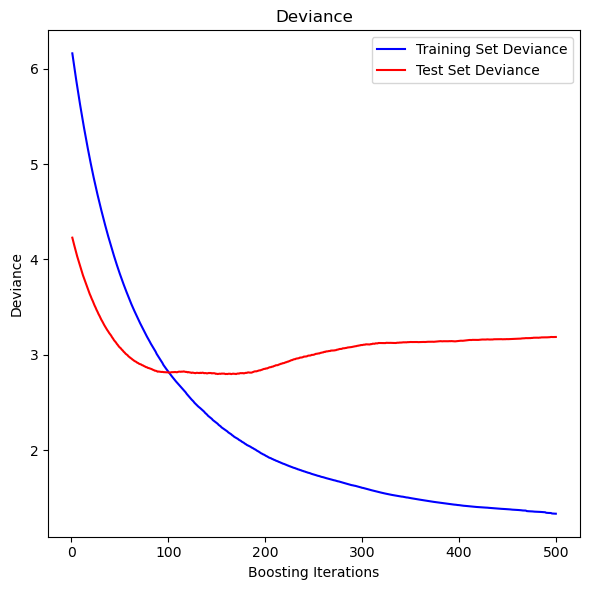

```python
test_score = np.zeros((params["n_estimators"],), dtype=np.float64)
for i, y_pred in enumerate(reg.staged_predict(X_test)):
    test_score[i] = mean_squared_error(y_test, y_pred)

fig = plt.figure(figsize=(6, 6))
plt.subplot(1, 1, 1)
plt.title("Deviance")
plt.plot(
    np.arange(params["n_estimators"]) + 1,
    reg.train_score_,
    "b-",
    label="Training Set Deviance",
)
plt.plot(
    np.arange(params["n_estimators"]) + 1, test_score, "r-", label="Test Set Deviance"
)
plt.legend(loc="upper right")
plt.xlabel("Boosting Iterations")
plt.ylabel("Deviance")
fig.tight_layout()
plt.show()
```

# Results

Durch die Datenanalyse konnten wir die Zusammenhänge der Variablen erkennen und unser Lineares Regressionsmodell bestmöglich aufbauen. Störfaktoren in Form von Korrelation zwischen den Prädiktorvariablen wie “sex_M” und “sex_F” oder “op_duration” und “recording_duration” wurden aufgezeigt und konnten eliminiert werden.

Nun können wir uns noch einmal die Ergebnisse, in Form der berechneten Gütmaße, des besten Linearen Regressionsmodells und des Lasso Regressionsmodells gegenüber ansehen.

```python
results = pd.DataFrame({'': ['R²','Adjusted R²','RMSE','MSE','MAE'],
                        'Lineare Regression': [(r2_score(y_test9, y_pred9).round(3)),
                        ((1-(1-r2_score(y_test9, y_pred9))*((len(X_test9)-1)/(len(X_test9)-len(X_test9.columns)-1))).round(4)),
                        (mean_squared_error(y_test9, y_pred9, squared=False).round(3)),
                        (mean_squared_error(y_test9, y_pred9).round(3)),
                        (mean_absolute_error(y_test9, y_pred9).round(3))],
                        'Lasso-Regression': [(r2_score(y_test, y_pred).round(3)),
                        ((1-(1-r2_score(y_test, y_pred))*((len(X_test)-1)/(len(X_test)-len(X_test.columns)-1))).round(4)),
                        (mean_squared_error(y_test, y_pred, squared=False).round(3)),
                        (mean_squared_error(y_test, y_pred).round(3)),
                        (mean_absolute_error(y_test, y_pred).round(3))]})

results
```

[output not shown]

Bei der Gegenüberstellung der Modelle fällt auf, dass das Lineare Regressionsmodell anhand aller Gütemaße mit Außnahme des Mean-Absolut-Error besser abschneidet als das Lasso-Regressionsmodell.

Der Adjusted R² - Wert zeigt uns, dass durch unser Modell nur etwa 14,3% der Variabilität der Aufenthaltsdauer erklärt.

# Discussion + Conclusion

In den Variablen erkennen wir, dass unsere Vorhersagevarible length_of_stay eine sehr große Streuung besitzt. Wir sehen eine Kollinearität zwischen den Variablen op_duration und recording_duration.

### Lineares Regressionsmodell:

Unser Modell sagt mit den Variablen “recording_duration”, “age”, “asa” und “bmi” die Aufenthaltsdauer von Patienten am besten voraus. Dennoch sehen wir in unserem Modell nur ein kleines adj. R², was für eine geringe Güte des Modells spricht. Nur etwa 14,3% der Variabilität der Aufenthaltsdauer werden durch das Modell erklärt. Des Weiteren zeigt der mean squared error der einzelnen Folds, dass es sich um kein sehr stabiles Modell handelt. Aus diesen Gründen, würden wir einem Krankenhaus nicht dazu raten mit diesen Variablen und diesem Modell zu versuchen die Aufenthaltsdauer der Patienten zu prognostizieren.

Mögliche Verbesserungen wären: Über Stratified sampling Gruppen bilden, um so Stichproben auszuwählen. Gruppen könnten beispielsweise sein:

- „Abteilungen“ in welchen die Patienten behandelt werden
- Art der Operation
- handelt es sich um eine geplante oder eine Notoperation

Weiterhin wäre es auch möglich gewesen Variablen mit einzubeziehen, welche über die Forschungsfrage hinaus gehen. Hier wären ebenfalls die Variablen „Abteilungen“ in welchen die Patienten behandelt werden, Art der Operation und Notoperation denkbare Variablen gewesen.